# ECONOMIA MONETÁRIA

João Vitor da Silva Santos

2024-09-30

# Teorias de Inflação, Moeda e História do Pensamento Inflacionário

# Pensadores

## Efeito Cantillon

O **“efeito Cantillon”** refere-se a uma teoria econômica proposta pelo economista irlandês **Richard Cantillon** no século XVIII. Ele argumentava que mudanças na oferta de moeda não afetam uniformemente toda a economia, mas beneficiam os primeiros a receber essa nova moeda antes que ela se espalhe por toda a sociedade, causando aumentos de preços.

[figure not shown]

## John Locke (1632–1704)

Locke foi um dos primeiros a teorizar sobre a inflação em relação à quantidade de moeda em circulação. Ele argumentava que a inflação ocorria quando havia uma expansão excessiva da moeda em relação à quantidade de bens disponíveis. Para ele, a desvalorização da moeda, especialmente quando não estava mais ligada a metais preciosos como o ouro e a prata, levava ao aumento dos preços, o que prejudicava o poder de compra das pessoas.

[figure not shown]

## David Hume (1711–1776)

Hume contribuiu para a ideia de que a inflação é o resultado de um aumento na oferta de moeda. Ele desenvolveu a teoria da “neutralidade da moeda” no longo prazo, onde um aumento na oferta monetária não afeta o crescimento econômico real, mas apenas os preços. Hume também discutiu o conceito de “fluxo de metais preciosos”, observando que um influxo de ouro e prata em um país (como resultado de uma balança comercial favorável) levaria a um aumento nos preços e, portanto, à inflação.

[figure not shown]

## Adam Smith (1723–1790)

Smith considerava a inflação como um fenômeno relacionado ao excesso de moeda em circulação em relação aos bens e serviços disponíveis. Em sua obra “A Riqueza das Nações”, ele defendeu que a moeda deveria ser uma mercadoria com valor intrínseco (como o ouro e a prata) para evitar a depreciação e a inflação. Para Smith, a inflação desvalorizava a moeda e prejudicava os indivíduos com renda fixa.

[figure not shown]

## David Ricardo (1772–1823)

Ricardo acreditava que a inflação era causada pelo excesso de emissão de papel-moeda sem o correspondente lastro em metais preciosos (como o ouro). Ele argumentou que, quando o governo emitia mais papel-moeda do que a quantidade de ouro em reserva, isso levava a um aumento dos preços, resultando em inflação. Ricardo defendia o padrão-ouro como uma maneira de estabilizar a moeda e controlar a inflação.

[figure not shown]

## Irving Fisher (1867–1947)

Fisher foi um dos primeiros economistas a desenvolver uma teoria quantitativa da moeda, que liga diretamente a oferta de moeda à inflação. Sua famosa equação MV = PQ (onde M é a quantidade de moeda, V é a velocidade de circulação da moeda, P é o nível de preços e Q é o volume de bens e serviços) propunha que um aumento na quantidade de moeda (M) levaria a um aumento nos preços (P), desde que a produção (Q) permanecesse constante. Fisher também analisou a deflação por dívida, destacando que crises econômicas poderiam ser exacerbadas pela queda nos preços e no valor dos ativos.

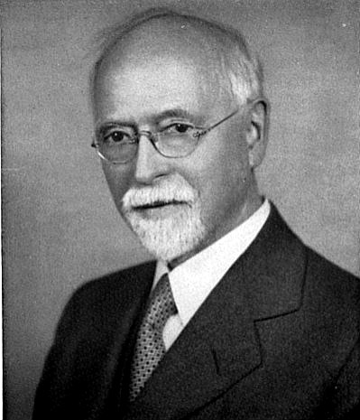

## John Maynard Keynes (1883–1946)

Keynes acreditava que a inflação era um problema principalmente em períodos de pleno emprego, quando a demanda agregada excedia a oferta. Ele argumentou que o aumento da demanda poderia ser benéfico em tempos de recessão, estimulando a produção e o emprego, mas poderia se tornar inflacionário quando a economia estivesse operando em plena capacidade. Keynes acreditava que o governo deveria controlar a demanda agregada por meio de políticas fiscais e monetárias para evitar tanto a inflação quanto o desemprego.

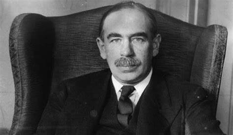

## Milton Friedman (1912–2006)

Friedman é conhecido por sua afirmação de que “a inflação é sempre e em toda parte um fenômeno monetário”. Ele argumentou que a inflação era causada por um aumento na oferta de moeda que excedia o crescimento econômico. Friedman foi um dos principais defensores do monetarismo, uma escola de pensamento que enfatiza o controle da oferta de moeda como a chave para gerenciar a inflação. Ele criticava políticas que tentavam combater a inflação por meio de controles de preços, defendendo que o controle da inflação dependia do controle do crescimento da moeda.

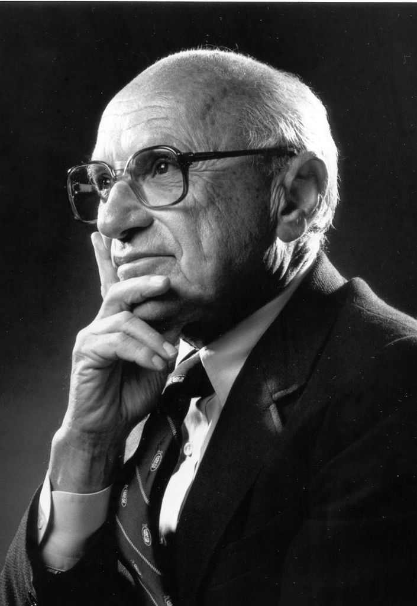

## Friedrich Hayek (1899–1992)

Hayek, da Escola Austríaca, via a inflação como o resultado de uma expansão monetária artificial, particularmente em períodos de intervenção estatal no mercado. Ele argumentava que a expansão do crédito e da moeda por parte dos bancos centrais distorcia os sinais de preços, levando a um “boom” econômico artificial, seguido de uma crise (“bust”) quando a inflação subisse ou o crédito se contraísse. Hayek defendia uma política monetária restritiva e menos intervenção governamental para evitar essas distorções e seus efeitos inflacionários.

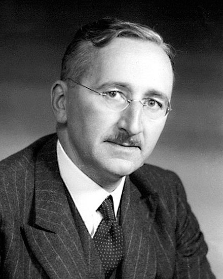

## Ludwig von Mises (1881–1973)

Mises, outro expoente da Escola Austríaca, argumentava que a inflação é uma expansão artificial da oferta monetária, geralmente promovida por governos ou bancos centrais. Ele acreditava que a inflação criava bolhas econômicas e distorcia os investimentos, levando a ciclos de expansão e recessão. Para Mises, a inflação era uma forma de imposto oculto, pois corroía o poder de compra do dinheiro, especialmente para as pessoas com rendas fixas.

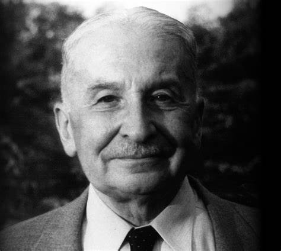

## Robert Lucas (1937–2023)

Lucas, um dos principais economistas da Escola de Expectativas Racionais, desafiou a visão keynesiana tradicional sobre a inflação. Ele argumentou que, em vez de ser surpreendida pela inflação, a população ajusta suas expectativas com base nas políticas do governo. Assim, as tentativas de estimular a economia por meio de expansão monetária apenas levariam à inflação sem ganhos duradouros em termos de emprego. Lucas acreditava que a política monetária só teria efeito se fosse inesperada, pois os agentes econômicos se ajustariam rapidamente às mudanças nas políticas.

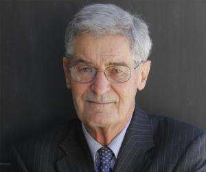

# Teorias

## Teoria Monetária Moderna (MMT)

A Teoria Monetária Moderna (MMT) propõe que governos que emitem sua própria moeda (como o Brasil com o real) não enfrentam os mesmos limites financeiros que indivíduos ou empresas. Segundo a MMT, o governo pode criar dinheiro para financiar seus gastos sem a necessidade de arrecadar impostos ou tomar empréstimos. O verdadeiro limite para os gastos governamentais não é o déficit ou a dívida, mas sim a inflação.

Os impostos, nessa visão, servem principalmente para controlar a inflação e redistribuir riqueza, e não para “financiar” o governo. A MMT também sugere a criação de um Programa de Emprego Garantido para assegurar o pleno emprego e estabilizar a economia. Embora a MMT tenha ganhado apoio em certos círculos, ela enfrenta críticas, especialmente por temores de que possa gerar inflação descontrolada se mal implementada.

## Inflação Inercial

A **inflação inercial** ocorre quando a inflação persiste ao longo do tempo devido a expectativas e reajustes automáticos de preços e salários, baseados na inflação passada. Mesmo sem novos choques econômicos, a inflação continua porque trabalhadores pedem aumentos salariais para compensar a perda de poder de compra, e empresas aumentam os preços para cobrir esses custos. Esse ciclo se retroalimenta, dificultando a queda da inflação. No Brasil, a inflação inercial foi um problema nos anos 1980 e 1990, resolvido em parte com o **Plano Real**, que quebrou a indexação automática de preços.

## Curva de Phillips

A Curva de Phillips representa a relação inversa entre a taxa de desemprego e a taxa de inflação em uma economia. Originalmente proposta por A.W. Phillips em 1958, a curva sugere que quando o desemprego é baixo, a inflação tende a ser alta, e vice-versa.

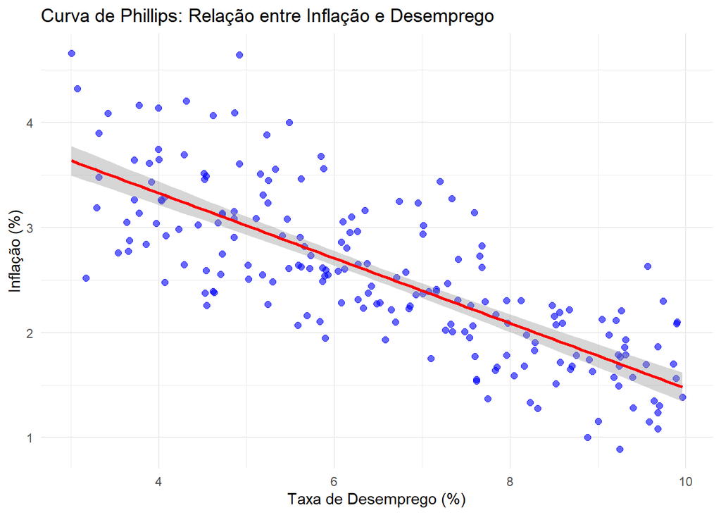